# Decision Tree, Random Forest, Boosting

## Decision Tree

Необходимые библиотеки для построения и визуализации Decision Tree:

```r
library(rpart)
library(caTools)
library(ggplot2)
library(dplyr)
```

Набор данных, содержащий информацию о том, что покупает ли человек товар на основе своего возраста и предполагаемой зарплаты. Мы имеем 400 наблюдений и 5 переменных.

**User.ID** — идентификатор пользователя (числовая).

**Gender** — пол пользователя (категориальная).

**Age** — возраст пользователя (числовая).

**EstimatedSalary** — предполагаемая зарплата пользователя (числовая).

**Purchased** — бинарный показатель покупки (0 = не купил, 1 = купил).

```r
dataset <- read.csv("C:\\Users\\Dolan\\Desktop\\R\\detree_rf_boost\\data.csv")
head(dataset, 20)
```

```
##     User.ID Gender Age EstimatedSalary Purchased
## 1  15624510   Male  19           19000         0
## 2  15810944   Male  35           20000         0
## 3  15668575 Female  26           43000         0
## 4  15603246 Female  27           57000         0
## 5  15804002   Male  19           76000         0
## 6  15728773   Male  27           58000         0
## 7  15598044 Female  27           84000         0
## 8  15694829 Female  32          150000         1
## 9  15600575   Male  25           33000         0
## 10 15727311 Female  35           65000         0
## 11 15570769 Female  26           80000         0
## 12 15606274 Female  26           52000         0
## 13 15746139   Male  20           86000         0
## 14 15704987   Male  32           18000         0
## 15 15628972   Male  18           82000         0
## 16 15697686   Male  29           80000         0
## 17 15733883   Male  47           25000         1
## 18 15617482   Male  45           26000         1
## 19 15704583   Male  46           28000         1
## 20 15621083 Female  48           29000         1
```

Разбиваем набор данных на обучающий и тестовый набор.

**factor()** — преобразует числовую переменную в категориальную переменную.

**sample.split()** — разбивает данные на обучающую и тестовую выборки.

**subset()** — создает подмножества данных на основе условия.

```r
dataset$Purchased <- factor(dataset$Purchased, levels = c(0, 1))

set.seed(123)
split <- sample.split(dataset$Purchased, SplitRatio = 0.75)
training_set <- subset(dataset, split == TRUE)
test_set <- subset(dataset, split == FALSE)

training_set_original <- training_set
test_set_original <- test_set
```

Стандартизируем числовые признаки, чтобы гарантировать, что все значения имеют одинаковый масштаб.

**scale()** — нормализует числовые значения до среднего значения 0 и стандартного отклонения 1.

```r
training_set[c("Age", "EstimatedSalary")] <- scale(training_set[c("Age", "EstimatedSalary")])
test_set[c("Age", "EstimatedSalary")] <- scale(test_set[c("Age", "EstimatedSalary")])

training_set_original[c("Age", "EstimatedSalary")] <- dataset[split == TRUE, c("Age", "EstimatedSalary")]
test_set_original[c("Age", "EstimatedSalary")] <- dataset[split == FALSE, c("Age", "EstimatedSalary")]
```

Обучаем классификатор дерева решений на обучающих данных:

```r
classifier <- rpart(formula = Purchased ~ Age + EstimatedSalary,
                    data = training_set,
                    method = "class")

classifier_original <- rpart(formula = Purchased ~ Age + EstimatedSalary,
                    data = training_set_original,
                    method = "class")
```

Прогнозируем метки классов для тестовых данных с помощью обученной модели:

```r
y_pred <- predict(classifier, newdata = test_set[c("Age", "EstimatedSalary")], type = "class")
```

Создаем матрицу несоответствий и визуализируем ее, чтобы понять производительность модели:

```r
cm <- table(test_set$Purchased, y_pred)
print(cm)
```

```
##    y_pred
##      0  1
##   0 53 11
##   1  6 30
```

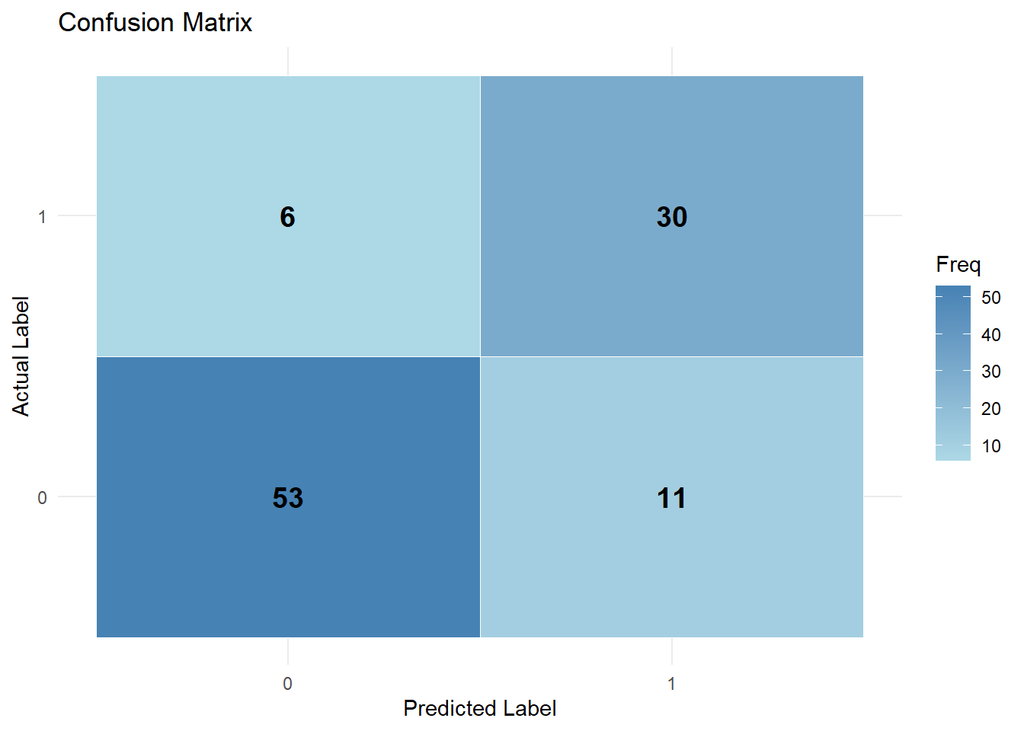

```r
cm_df <- as.data.frame(cm)
colnames(cm_df) <- c("Actual", "Predicted", "Freq")

ggplot(cm_df, aes(x = Predicted, y = Actual)) +
  geom_tile(aes(fill = Freq), color = "white") +
  geom_text(aes(label = Freq), vjust = 0.5, fontface = "bold", size = 5) +
  scale_fill_gradient(low = "lightblue", high = "steelblue") +
  labs(title = "Confusion Matrix", x = "Predicted Label", y = "Actual Label") +
  theme_minimal()
```

Визуализация границ принятия решений (обучающий набор):

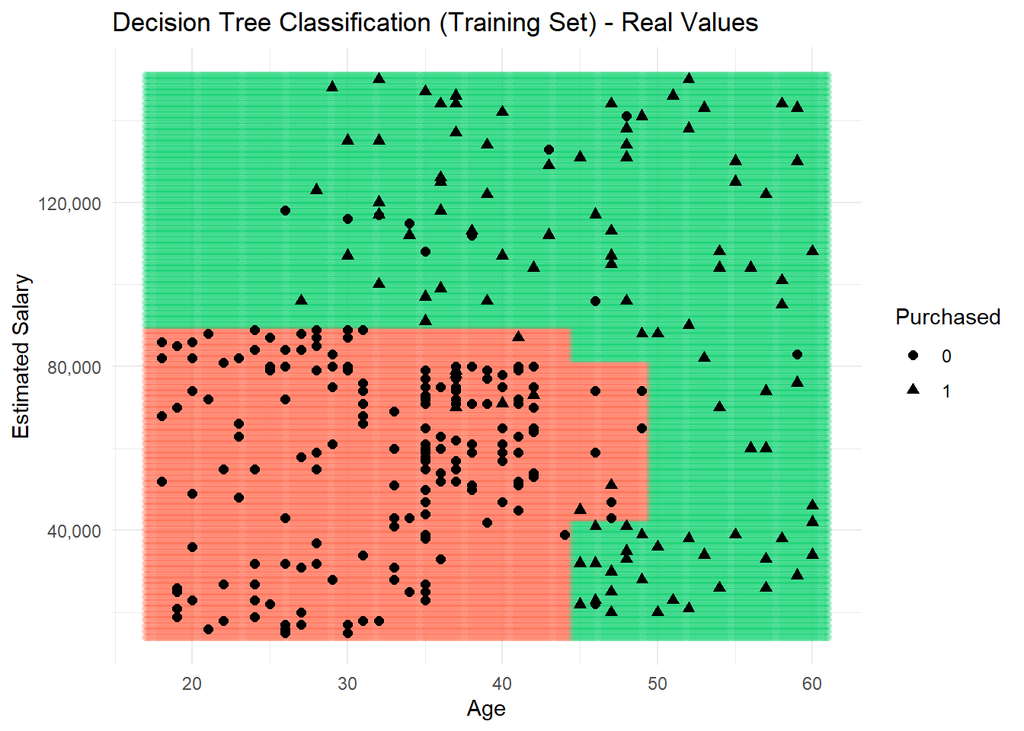

```r
x_min <- min(training_set_original$Age) - 1
x_max <- max(training_set_original$Age) + 1
y_min <- min(training_set_original$EstimatedSalary) - 1000
y_max <- max(training_set_original$EstimatedSalary) + 1000

grid_set <- expand.grid(
  Age = seq(x_min, x_max, by = 0.1),
  EstimatedSalary = seq(y_min, y_max, length.out = 100)
)

grid_set$Purchased <- predict(classifier_original, newdata = grid_set, type = "class")

ggplot() +
  geom_point(data = grid_set, aes(x = Age, y = EstimatedSalary, color = Purchased), alpha = 0.2) +
  geom_point(data = training_set_original, aes(x = Age, y = EstimatedSalary, shape = Purchased, fill = Purchased), size = 2) +
  labs(title = "Decision Tree Classification (Training Set) - Real Values",
       x = "Age", y = "Estimated Salary") +
  scale_color_manual(values = c("tomato", "springgreen3")) +
  scale_fill_manual(values = c("red3", "green4")) +
  scale_y_continuous(labels = scales::comma) +  # Форматирование зарплаты
  theme_minimal()
```

Визуализация границ принятия решений (тестовый набор):

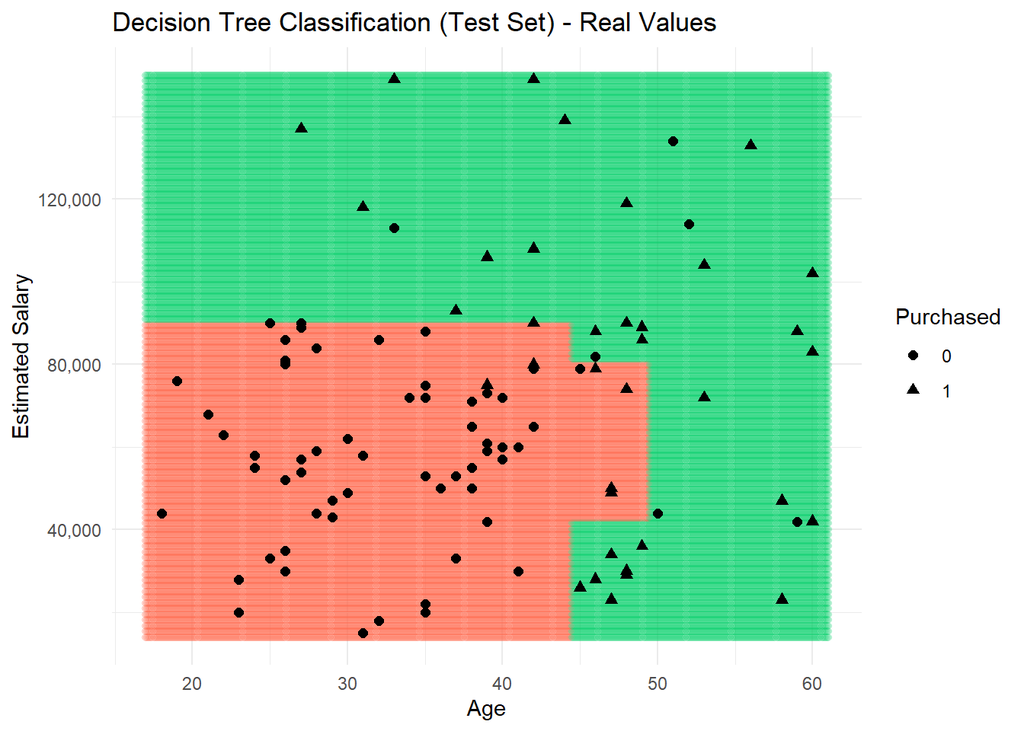

```r
x_min <- min(test_set_original$Age) - 1
x_max <- max(test_set_original$Age) + 1
y_min <- min(test_set_original$EstimatedSalary) - 1000
y_max <- max(test_set_original$EstimatedSalary) + 1000

grid_set <- expand.grid(
  Age = seq(x_min, x_max, by = 0.1),
  EstimatedSalary = seq(y_min, y_max, length.out = 100)
)

grid_set$Purchased <- predict(classifier_original, newdata = grid_set, type = "class")

ggplot() +
  geom_point(data = grid_set, aes(x = Age, y = EstimatedSalary, color = Purchased), alpha = 0.2) +
  geom_point(data = test_set_original, aes(x = Age, y = EstimatedSalary, shape = Purchased, fill = Purchased), size = 2) +
  labs(title = "Decision Tree Classification (Test Set) - Real Values",
       x = "Age", y = "Estimated Salary") +
  scale_color_manual(values = c("tomato", "springgreen3")) +
  scale_fill_manual(values = c("red3", "green4")) +
  scale_y_continuous(labels = scales::comma) +  # Форматирование зарплаты
  theme_minimal()
```

Визуализация дерева принятия решений:

Ниже показано **Decision Tree**, которое классифицирует, купит ли человек товар на основе его возраста и предполагаемой зарплаты. Сначала проверяется возраст, а затем идет дополнительное разделение на основе значений заработной платы. Каждый путь заканчивается прогнозом класса 0 или 1, представляющим окончательное решение модели.

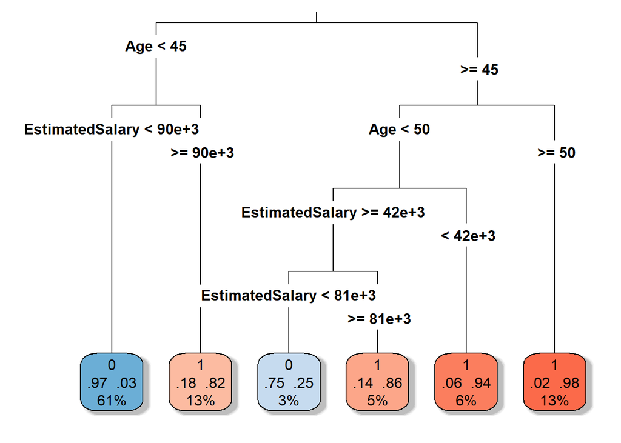

```r
library(rpart.plot)
rpart.plot(classifier_original,
           type = 3,
           extra = 104,
           fallen.leaves = TRUE,
           box.palette = "BuRd",
           shadow.col = "gray")
```

## Random Forest

```r
library(randomForest)
```

Обучаем классификатор случайного леса на обучающих данных:

```r
set.seed(123)
rf_classifier <- randomForest(x = training_set[c("Age", "EstimatedSalary")],
                              y = training_set$Purchased,
                              ntree = 500)

rf_classifier_original <- randomForest(x = training_set_original[c("Age", "EstimatedSalary")],
                                       y = training_set_original$Purchased,
                                       ntree = 500)
```

Прогнозируем метки классов для тестовых данных с помощью обученной модели:

```r
y_pred_rf <- predict(rf_classifier, newdata = test_set[c("Age", "EstimatedSalary")])
```

Создаем матрицу несоответствий и визуализируем ее:

```r
cm_rf <- table(test_set$Purchased, y_pred_rf)
print(cm_rf)
```

```
##    y_pred_rf
##      0  1
##   0 56  8
##   1  7 29
```

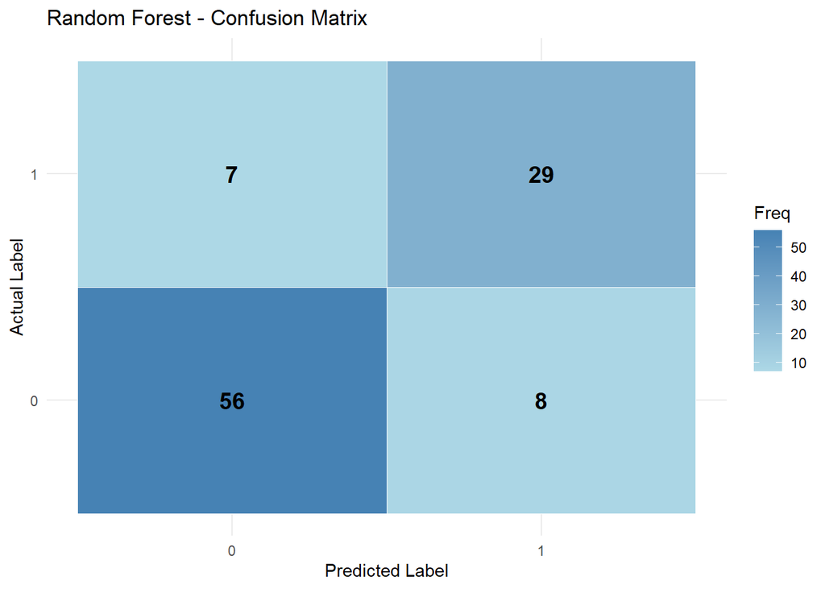

```r
cm_rf_df <- as.data.frame(cm_rf)
colnames(cm_rf_df) <- c("Actual", "Predicted", "Freq")

ggplot(cm_rf_df, aes(x = Predicted, y = Actual)) +
  geom_tile(aes(fill = Freq), color = "white") +
  geom_text(aes(label = Freq), vjust = 0.5, fontface = "bold", size = 5) +
  scale_fill_gradient(low = "lightblue", high = "steelblue") +
  labs(title = "Random Forest - Confusion Matrix", x = "Predicted Label", y = "Actual Label") +
  theme_minimal()
```

Визуализация границ принятия решений (обучающий набор):

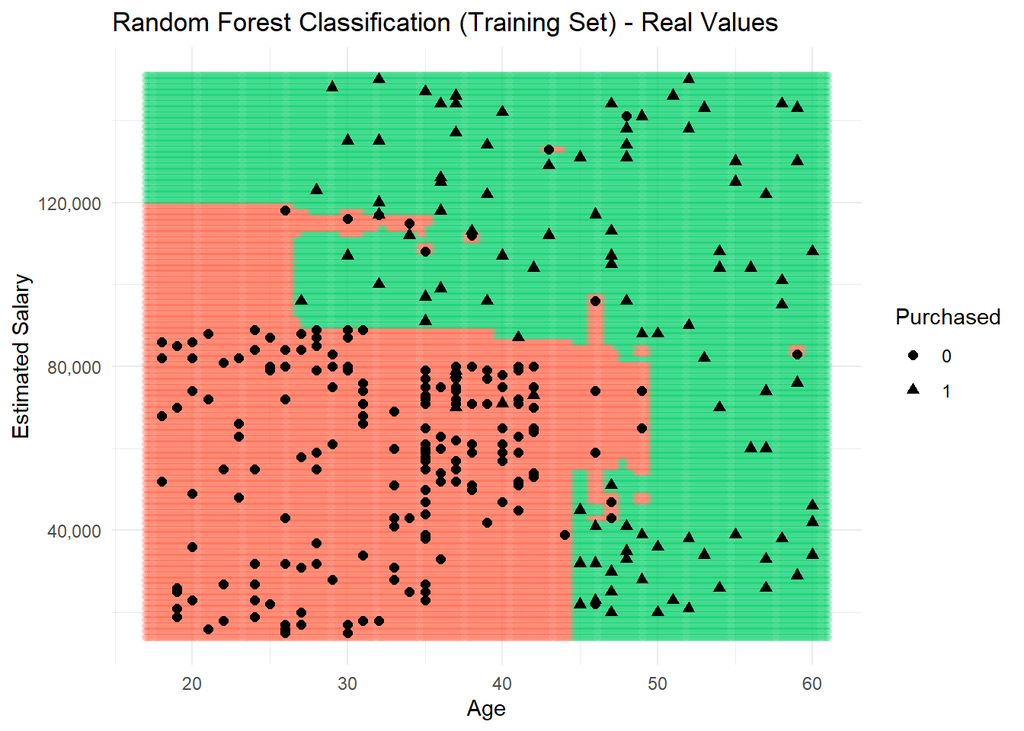

```r
x_min <- min(training_set_original$Age) - 1
x_max <- max(training_set_original$Age) + 1
y_min <- min(training_set_original$EstimatedSalary) - 1000
y_max <- max(training_set_original$EstimatedSalary) + 1000

grid_set <- expand.grid(
  Age = seq(x_min, x_max, by = 0.1),
  EstimatedSalary = seq(y_min, y_max, length.out = 100)
)

grid_set$Purchased <- predict(rf_classifier_original, newdata = grid_set)

ggplot() +
  geom_point(data = grid_set, aes(x = Age, y = EstimatedSalary, color = Purchased), alpha = 0.2) +
  geom_point(data = training_set_original, aes(x = Age, y = EstimatedSalary, shape = Purchased, fill = Purchased), size = 2) +
  labs(title = "Random Forest Classification (Training Set) - Real Values",
       x = "Age", y = "Estimated Salary") +
  scale_color_manual(values = c("tomato", "springgreen3")) +
  scale_fill_manual(values = c("red3", "green4")) +
  scale_y_continuous(labels = scales::comma) +
  theme_minimal()
```

Визуализация границ принятия решений (тестовый набор):

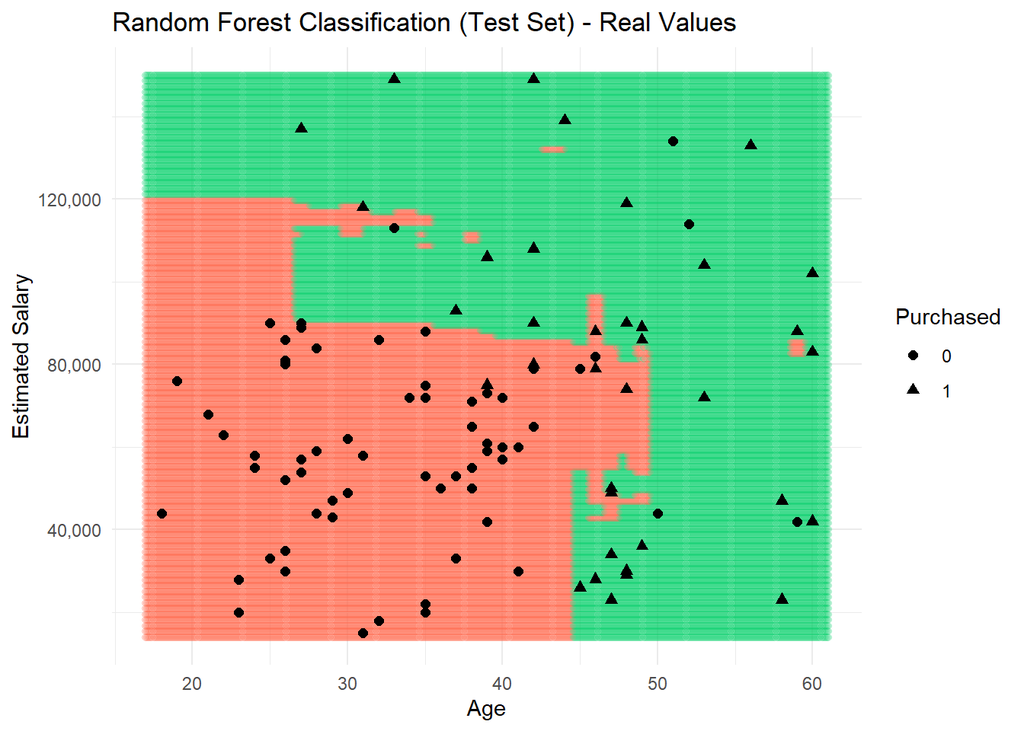

```r
x_min <- min(test_set_original$Age) - 1
x_max <- max(test_set_original$Age) + 1
y_min <- min(test_set_original$EstimatedSalary) - 1000
y_max <- max(test_set_original$EstimatedSalary) + 1000

grid_set <- expand.grid(
  Age = seq(x_min, x_max, by = 0.1),
  EstimatedSalary = seq(y_min, y_max, length.out = 100)
)

grid_set$Purchased <- predict(rf_classifier_original, newdata = grid_set)

ggplot() +
  geom_point(data = grid_set, aes(x = Age, y = EstimatedSalary, color = Purchased), alpha = 0.2) +
  geom_point(data = test_set_original, aes(x = Age, y = EstimatedSalary, shape = Purchased, fill = Purchased), size = 2) +
  labs(title = "Random Forest Classification (Test Set) - Real Values",
       x = "Age", y = "Estimated Salary") +
  scale_color_manual(values = c("tomato", "springgreen3")) +
  scale_fill_manual(values = c("red3", "green4")) +
  scale_y_continuous(labels = scales::comma) +
  theme_minimal()
```

Оценим важность каждой переменной:

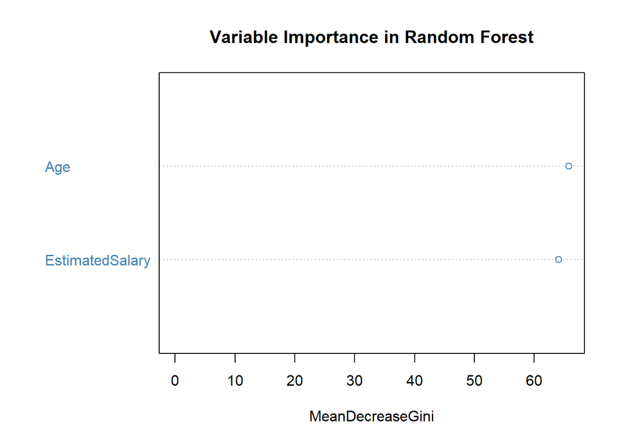

```r
importance_rf <- importance(rf_classifier_original)
varImpPlot(rf_classifier_original,
           main = "Variable Importance in Random Forest",
           col = "steelblue")
```

```r
print(importance_rf)
```

```
##                 MeanDecreaseGini
## Age                     65.76427
## EstimatedSalary         64.06323
```

Точность **Decision Tree**:

```r
dt_accuracy <- sum(diag(cm)) / sum(cm)
cat("Decision Tree Accuracy:", dt_accuracy, "\n")
```

```
## Decision Tree Accuracy: 0.83
```

Точность **Random Forest**:

```r
# Точность Random Forest
rf_accuracy <- sum(diag(cm_rf)) / sum(cm_rf)
cat("Random Forest Accuracy:", rf_accuracy, "\n")
```

```
## Random Forest Accuracy: 0.85
```

Сравнение точности **Decision Tree** и **Random Forest**:

```r
if(rf_accuracy > dt_accuracy) {
  cat("Random Forest показал лучшую производительность на", round((rf_accuracy - dt_accuracy) * 100, 2), "%\n")
} else {
  cat("Decision Tree показал лучшую производительность на", round((dt_accuracy - rf_accuracy) * 100, 2), "%\n")
}
```

```
## Random Forest показал лучшую производительность на 2 %
```

## Boosting (AdaBoost)

```r
library(adabag)
```

Обучаем классификатор **AdaBoost** на обучающих данных:

```r
set.seed(123)
ada_classifier <- boosting(Purchased ~ Age + EstimatedSalary,
                          data = training_set,
                          boos = TRUE,
                          mfinal = 50)

ada_classifier_original <- boosting(Purchased ~ Age + EstimatedSalary,
                                   data = training_set_original,
                                   boos = TRUE,
                                   mfinal = 50)
```

Прогнозируем метки классов для тестовых данных с помощью обученной модели:

```r
y_pred_ada <- predict(ada_classifier, newdata = test_set[c("Age", "EstimatedSalary")])
y_pred_ada_class <- y_pred_ada$class
```

Создаем матрицу несоответствий и визуализируем ее:

```r
cm_ada <- table(test_set$Purchased, y_pred_ada_class)
print(cm_ada)
```

```
##    y_pred_ada_class
##      0  1
##   0 56  8
##   1  6 30
```

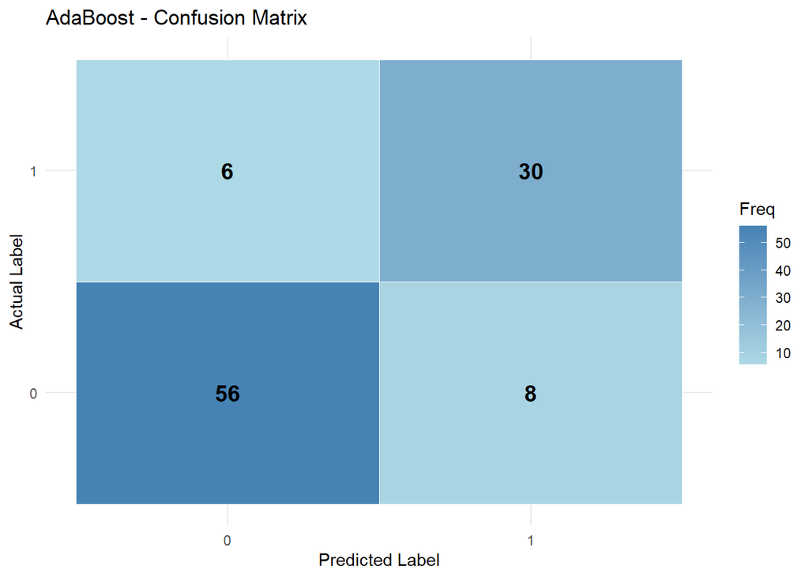

```r
cm_ada_df <- as.data.frame(cm_ada)
colnames(cm_ada_df) <- c("Actual", "Predicted", "Freq")

ggplot(cm_ada_df, aes(x = Predicted, y = Actual)) +
  geom_tile(aes(fill = Freq), color = "white") +
  geom_text(aes(label = Freq), vjust = 0.5, fontface = "bold", size = 5) +
  scale_fill_gradient(low = "lightblue", high = "steelblue") +
  labs(title = "AdaBoost - Confusion Matrix", x = "Predicted Label", y = "Actual Label") +
  theme_minimal()
```

Визуализация границ принятия решений (обучающий набор):

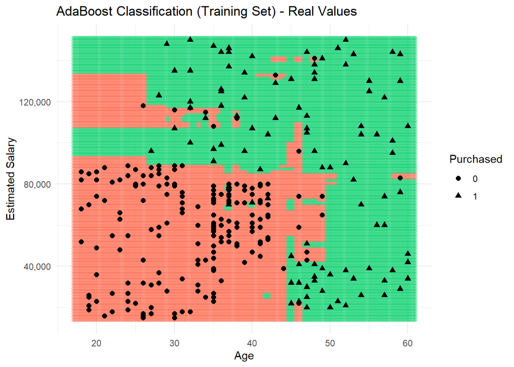

```r
x_min <- min(training_set_original$Age) - 1
x_max <- max(training_set_original$Age) + 1
y_min <- min(training_set_original$EstimatedSalary) - 1000
y_max <- max(training_set_original$EstimatedSalary) + 1000

grid_set <- expand.grid(
  Age = seq(x_min, x_max, by = 0.1),
  EstimatedSalary = seq(y_min, y_max, length.out = 100)
)

grid_pred <- predict(ada_classifier_original, newdata = grid_set)
grid_set$Purchased <- grid_pred$class

ggplot() +
  geom_point(data = grid_set, aes(x = Age, y = EstimatedSalary, color = Purchased), alpha = 0.2) +
  geom_point(data = training_set_original, aes(x = Age, y = EstimatedSalary, shape = Purchased, fill = Purchased), size = 2) +
  labs(title = "AdaBoost Classification (Training Set) - Real Values",
       x = "Age", y = "Estimated Salary") +
  scale_color_manual(values = c("tomato", "springgreen3")) +
  scale_fill_manual(values = c("red3", "green4")) +
  scale_y_continuous(labels = scales::comma) +
  theme_minimal()
```

Визуализация границ принятия решений (тестовый набор):

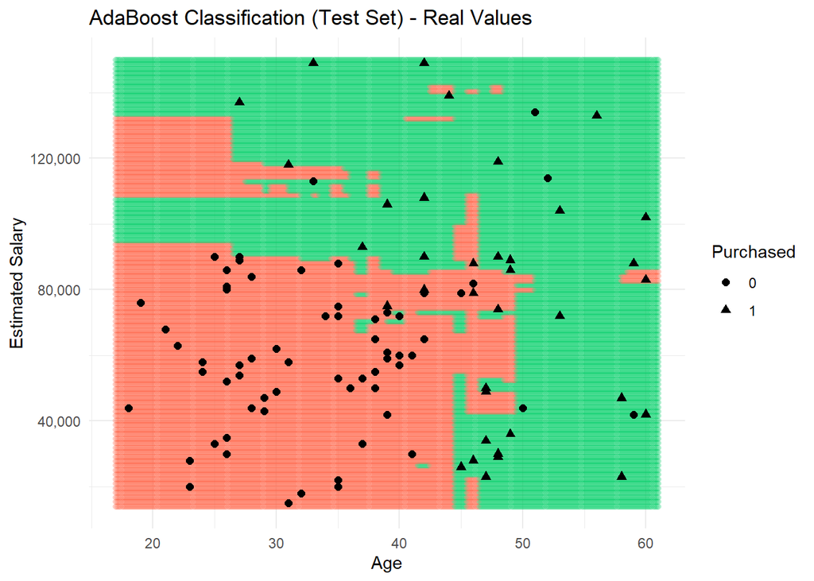

```r
x_min <- min(test_set_original$Age) - 1
x_max <- max(test_set_original$Age) + 1
y_min <- min(test_set_original$EstimatedSalary) - 1000
y_max <- max(test_set_original$EstimatedSalary) + 1000

grid_set <- expand.grid(
  Age = seq(x_min, x_max, by = 0.1),
  EstimatedSalary = seq(y_min, y_max, length.out = 100)
)

grid_pred <- predict(ada_classifier_original, newdata = grid_set)
grid_set$Purchased <- grid_pred$class

ggplot() +
  geom_point(data = grid_set, aes(x = Age, y = EstimatedSalary, color = Purchased), alpha = 0.2) +
  geom_point(data = test_set_original, aes(x = Age, y = EstimatedSalary, shape = Purchased, fill = Purchased), size = 2) +
  labs(title = "AdaBoost Classification (Test Set) - Real Values",
       x = "Age", y = "Estimated Salary") +
  scale_color_manual(values = c("tomato", "springgreen3")) +
  scale_fill_manual(values = c("red3", "green4")) +
  scale_y_continuous(labels = scales::comma) +
  theme_minimal()
```

Оценим важность каждой переменной:

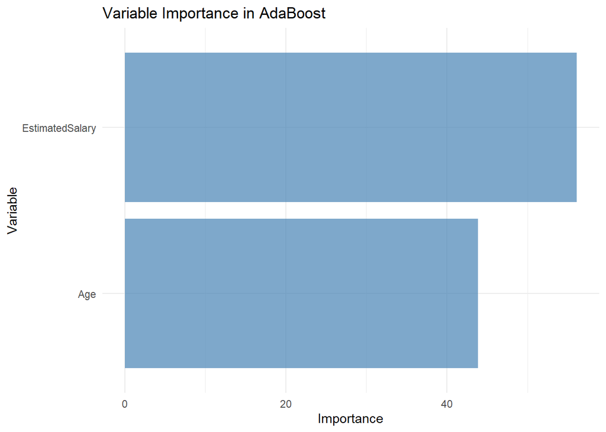

```r
importance_ada <- ada_classifier_original$importance
importance_df <- data.frame(
  Variable = names(importance_ada),
  Importance = importance_ada
)

ggplot(importance_df, aes(x = reorder(Variable, Importance), y = Importance)) +
  geom_bar(stat = "identity", fill = "steelblue", alpha = 0.7) +
  coord_flip() +
  labs(title = "Variable Importance in AdaBoost",
       x = "Variable",
       y = "Importance") +
  theme_minimal()
```

```r
print(importance_ada)
```

```
##             Age EstimatedSalary
##        43.88773        56.11227
```

Точность **AdaBoost**:

```r
ada_accuracy <- sum(diag(cm_ada)) / sum(cm_ada)
cat("AdaBoost Accuracy:", ada_accuracy, "\n")
```

```
## AdaBoost Accuracy: 0.86
```

Сравнение точности всех трех моделей:

```r
cat("Decision Tree Accuracy:", dt_accuracy, "\n")
```

```
## Decision Tree Accuracy: 0.83
```

```r
cat("Random Forest Accuracy:", rf_accuracy, "\n")
```

```
## Random Forest Accuracy: 0.85
```

```r
cat("AdaBoost Accuracy:", ada_accuracy, "\n")
```

```
## AdaBoost Accuracy: 0.86
```

```r
accuracies <- c(dt_accuracy, rf_accuracy, ada_accuracy)
models <- c("Decision Tree", "Random Forest", "AdaBoost")
best_model <- models[which.max(accuracies)]
best_accuracy <- max(accuracies)

cat("\nЛучшая модель:", best_model, "с точностью", round(best_accuracy * 100, 2), "%\n")
```

```
##
## Лучшая модель: AdaBoost с точностью 86 %
```

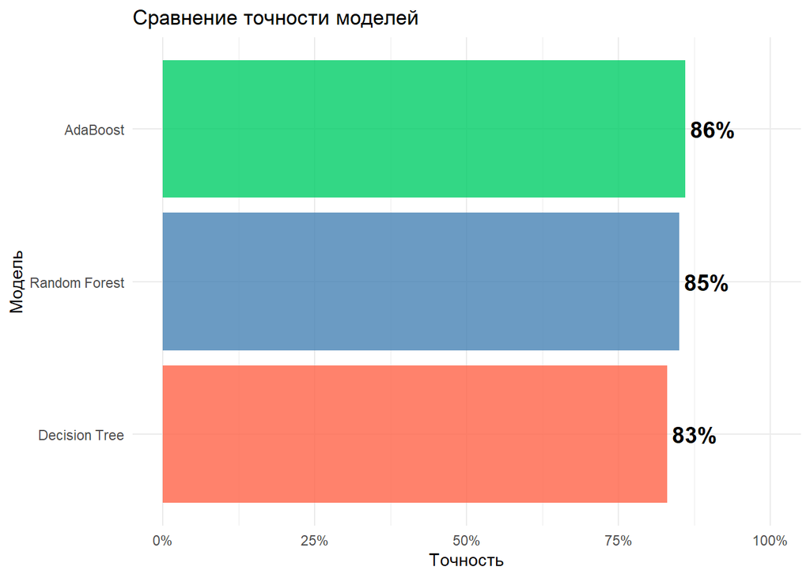

```r
comparison_df <- data.frame(
  Model = models,
  Accuracy = accuracies
)

ggplot(comparison_df, aes(x = reorder(Model, Accuracy), y = Accuracy)) +
  geom_bar(stat = "identity", aes(fill = Model), alpha = 0.8) +
  geom_text(aes(label = paste0(round(Accuracy * 100, 1), "%")),
            hjust = -0.1, size = 5, fontface = "bold") +
  scale_fill_manual(values = c("Decision Tree" = "tomato",
                              "Random Forest" = "steelblue",
                              "AdaBoost" = "springgreen3")) +
  labs(title = "Сравнение точности моделей",
       x = "Модель",
       y = "Точность") +
  scale_y_continuous(labels = scales::percent, limits = c(0, 1)) +
  coord_flip() +
  theme_minimal() +
  theme(legend.position = "none")
```